# Sentiment Analysis of #ASHE2016 Tweets

Will Doyle

# ASHE Words: How are people feeling?

I’ve been discussing web scraping with students at LPO/Peabody, and I wanted to give a brief demonstration regarding how to do a sentiment analysis using twitter. What better way to do this than to track how people are feeling as they get ready for the ASHE conference in Columbus?

The code I’ll use here is [ahem]*adapted* from the nifty sentiment analysis of Trump tweets by David Robinson [here](http://varianceexplained.org/r/trump-tweets/). It also owes a ton to the creates of the [twitteR](https://cran.r-project.org/web/packages/twitteR/index.html) package and the [tidytext](https://cran.r-project.org/web/packages/tidytext/vignettes/tidytext.html) package.

The full github repo for this work is [here](https://github.com/wdoyle42/ashe_2016_twitter). You can get the `ashe_2016_twitter.Rmd` file, which contains all of the code necessary to replicate this analysis.

I start out by grabbing the necessary R packages:

```r
library(tidyverse)
library(lubridate)
library(twitteR)
library(tidytext)
library(stringr)
library(readr)
```

## Get Tweets

The [Twitter API](https://dev.twitter.com/overview/api) allows users to directly download a limited number of tweets, using various search terms. The twitteR package provides a convenient R-based interface for using the API. Below, I set the consumer and access keys and tokens provide to me by Twitter (you’ll need your own) and then use the `searchTwitter` function to get all of the tweets from the previous day.

```r
## Keys: you'll need your own.
consumer_api_key<-"<your key here>"
consumer_secret<-"<your key here>"
access_token<-"<your key here>"
access_secret<-"<your key here>"

## My keys are stored in a separate file
keys<-read_csv("keys.txt",col_names=FALSE)
consumer_api_key<-keys$X1[1]
consumer_secret<-keys$X1[2]
access_token<-keys$X1[3]
access_secret<-keys$X1[4]


## Setup the authorization
setup_twitter_oauth(consumer_key =  consumer_api_key,
                    consumer_secret = consumer_secret,
                    access_token = access_token,
                    access_secret = access_secret)
```

```
## [1] "Using direct authentication"
```

```r
## Set date range-- I want all tweets from yesterday
today<-ymd(today())
yesterday<-today-1
two_days_ago<-today-2

## Key function: this gets the results
ashe_results<-searchTwitter(searchString = "ASHE2016",n=1000,
                            since = as.character(two_days_ago),
                            until= as.character(yesterday)
                            )
```

## Structure tweets as data

```r
df<-tbl_df(map_df(ashe_results, as.data.frame))
```

The text from each tweet is stored as a string. I want to get rid of “stop” words and then create a dataset that has one line per word in each tweet.

```r
reg <- "([^A-Za-z\\d#@']|'(?![A-Za-z\\d#@]))"
tweet_words_day <- df%>%
  filter(!str_detect(text, '^"')) %>%
  mutate(text = str_replace_all(text, "https://t.co/[A-Za-z\\d]+|&amp;", "")) %>%
  unnest_tokens(word, text, token = "regex", pattern = reg) %>%
  filter(!word %in% stop_words$word,
         str_detect(word, "[a-z]")) %>%tbl_df()
```

```r
tweet_words_day
```

```
## # A tibble: 488 × 16
##    favorited favoriteCount replyToSN             created truncated
##        <lgl>         <dbl>     <lgl>              <dttm>     <lgl>
## 1      FALSE             0        NA 2016-11-06 01:46:06     FALSE
## 2      FALSE             0        NA 2016-11-06 01:46:06     FALSE
## 3      FALSE             0        NA 2016-11-06 01:46:06     FALSE
## 4      FALSE             0        NA 2016-11-06 01:46:06     FALSE
## 5      FALSE             0        NA 2016-11-06 01:46:06     FALSE
## 6      FALSE             0        NA 2016-11-06 01:46:06     FALSE
## 7      FALSE             0        NA 2016-11-06 01:46:06     FALSE
## 8      FALSE             0        NA 2016-11-06 01:46:06     FALSE
## 9      FALSE             0        NA 2016-11-06 01:46:06     FALSE
## 10     FALSE             0        NA 2016-11-06 01:46:06     FALSE
## # ... with 478 more rows, and 11 more variables: replyToSID <lgl>,
## #   id <chr>, replyToUID <lgl>, statusSource <chr>, screenName <chr>,
## #   retweetCount <dbl>, isRetweet <lgl>, retweeted <lgl>, longitude <lgl>,
## #   latitude <lgl>, word <chr>
```

I’m going to add the day that these tweets come from, then save that dataset. There are other ways to do this.

```r
tweet_words_day<-tweet_words_day%>%mutate(day=yesterday)

save(tweet_words_day,file=paste0("ashe_words_",yesterday,".Rdata"))
```

## Get sentiments

Now I have data from each day, showing all of the words that were used that day. Next is to analyze sentiments. I need a lexicon that associates words with various sentiments. I’ll use the [nrc](http://saifmohammad.com/WebPages/NRC-Emotion-Lexicon.htm) lexicon to do this.

```r
nrc <- sentiments %>%
  filter(lexicon == "nrc") %>%
  select(word, sentiment)
```

Now to get all of the data previously stored. I started with Monday, 10/31/2016, and I go until today, loading all of the data from each day.

```r
startday<-ymd("2016-10-31")

seq_dates<-seq(startday,yesterday,by="days")

tweet_words<-NULL
for (date in as.character(seq_dates)){
load(paste0("ashe_words_",date,".Rdata"))
tweet_words<-rbind(tweet_words,tweet_words_day)
  }
```

Next, grab the sentiments and associate them with the words, then count the number of sentiments of each type expressed each day.

```r
by_day_sentiment <- tweet_words %>%
  inner_join(nrc, by = "word") %>%
  count(sentiment,day)
```

We can also see what the most common words are each day:

```r
by_day_common <-tweet_words%>%filter(word!="ashe2016",word!="rt")%>%
  mutate(hash_flag=ifelse(str_detect(word,"#"),1,0),
         at_flag=ifelse(str_detect(word,"@"),1,0),
         n=n())%>%
  group_by(day,at_flag,hash_flag)%>%
  count(word,sort=TRUE)

by_day_common%>%filter(hash_flag==1)
```

```
## Source: local data frame [61 x 5]
## Groups: day, at_flag, hash_flag [8]
##
##           day at_flag hash_flag       word    nn
##        <date>   <dbl>     <dbl>      <chr> <int>
## 1  2016-11-07       0         1  #ashe2016    36
## 2  2016-11-02       0         1  #ashe2016    28
## 3  2016-11-06       0         1  #ashe2016    26
## 4  2016-11-07       0         1      #gsps    24
## 5  2016-11-04       0         1  #ashe2016    22
## 6  2016-11-05       0         1  #ashe2016    19
## 7  2016-11-02       0         1 #ashegrads    17
## 8  2016-11-03       0         1  #ashe2016    17
## 9  2016-11-05       0         1      #aera    11
## 10 2016-11-05       0         1  #highered    11
## # ... with 51 more rows
```

```r
by_day_common%>%filter(at_flag==1)
```

```
## Source: local data frame [91 x 5]
## Groups: day, at_flag, hash_flag [7]
##
##           day at_flag hash_flag             word    nn
##        <date>   <dbl>     <dbl>            <chr> <int>
## 1  2016-11-07       1         0      @mkmclendon    17
## 2  2016-11-02       1         0       @ashegrads    15
## 3  2016-11-06       1         0      @asheoffice    13
## 4  2016-11-05       1         0       @ashegrads    12
## 5  2016-11-05       1         0         @aeradiv    11
## 6  2016-11-05       1         0 @aeradivjgradnet    11
## 7  2016-11-05       1         0      @asheoffice    11
## 8  2016-11-05       1         0         @amymetc    10
## 9  2016-11-04       1         0     @desimckeown     8
## 10 2016-11-04       1         0      @vicgoddard     8
## # ... with 81 more rows
```

```r
by_day_common%>%filter(hash_flag==0&at_flag==0)%>%select(day,word,nn)
```

```
## Source: local data frame [440 x 5]
## Groups: day, at_flag, hash_flag [8]
##
##    at_flag hash_flag        day       word    nn
##      <dbl>     <dbl>     <date>      <chr> <int>
## 1        0         0 2016-11-07        doc    19
## 2        0         0 2016-11-07    joining    19
## 3        0         0 2016-11-07   students    17
## 4        0         0 2016-11-05 indigenous    12
## 5        0         0 2016-11-06   columbus    12
## 6        0         0 2016-11-02     follow    11
## 7        0         0 2016-11-05   research    11
## 8        0         0 2016-11-05         wk    11
## 9        0         0 2016-11-04    schools    10
## 10       0         0 2016-11-04  selection    10
## # ... with 430 more rows
```

Here’s what the data look like:

```r
by_day_sentiment
```

```
## Source: local data frame [53 x 3]
## Groups: sentiment [?]
##
##       sentiment        day     n
##           <chr>     <date> <int>
## 1         anger 2016-11-01     2
## 2         anger 2016-11-02     3
## 3         anger 2016-11-04     2
## 4  anticipation 2016-11-01     2
## 5  anticipation 2016-11-02    17
## 6  anticipation 2016-11-03     5
## 7  anticipation 2016-11-04     4
## 8  anticipation 2016-11-05     3
## 9  anticipation 2016-11-06    19
## 10 anticipation 2016-11-07    17
## # ... with 43 more rows
```

## Plot the result

Now I’m ready to plot. Let’s start with a bar plot by day:

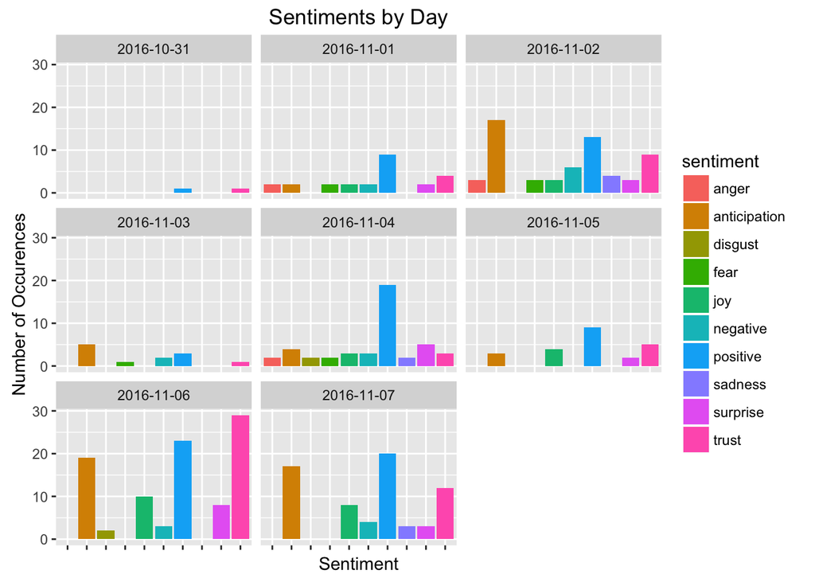

```r
gg<-ggplot(by_day_sentiment,aes(x=sentiment,y=n,fill=sentiment))
gg<-gg+geom_bar(stat="identity")
gg<-gg+facet_wrap(~day,ncol=3)
gg<-gg+scale_x_discrete(labels=element_blank())
gg<-gg+xlab("Sentiment")+ylab("Number of Occurences")+ggtitle("Sentiments by Day")
gg
```

And, how about a line plot (this should get better as we get closer)

## Sentiments by Day

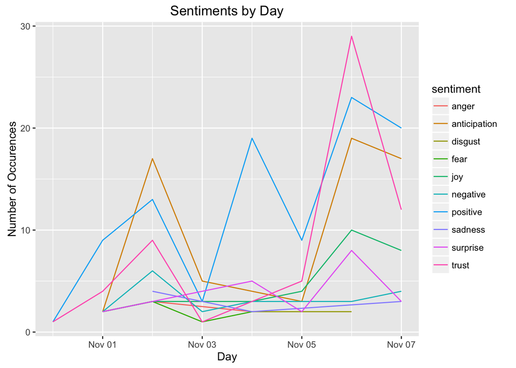

```r
gg<-ggplot(by_day_sentiment,aes(x=ymd(day),y=n,color=sentiment))
gg<-gg+geom_line()
gg<-gg+xlab("Day")+ylab("Number of Occurences")+ggtitle("Sentiments by Day")
gg
```